# Projet d’analyse exploratoire des données : Hotel Booking Demand

Exploration de données, Sciences des données appliquées, Collège La Cité

Yacine Lezoul (2748526)

Novembre 2026

**Dépôt GitHub (code source, données et rapport) :** github.com/lezoul/hotel-booking-eda-r

# 0. Préparation de l’environnement

Le package `tidyverse` regroupe tous les outils utilisés dans ce Notebook : `readr`, `dplyr`, `tidyr` et `ggplot2`.

```r
# À installer une seule fois si nécessaire :
# install.packages("tidyverse")
library(tidyverse)

# Thème graphique commun à tous les graphiques
theme_set(theme_minimal(base_size = 12))
couleurs_hotel <- c("City Hotel" = "#2563eb", "Resort Hotel" = "#0ea5e9")
couleurs_annul <- c("Non annulée" = "#16a34a", "Annulée" = "#dc2626")
```

# Mission 1 : Compréhension du contexte et formulation du problème

## 1.1 Le secteur étudié

Dans l’hôtellerie, la chambre est un produit périssable : une nuit non vendue est perdue pour toujours. Les annulations sont donc un enjeu central. Une annulation tardive libère une chambre qu’il est souvent trop tard pour revendre, ce qui pousse les hôtels à pratiquer la surréservation, à exiger des dépôts ou à ajuster leurs tarifs. Comprendre qui réserve, quand, par quel canal et à quel prix aide à mieux gérer les revenus (revenue management) et la capacité.

Le jeu de données **Hotel Booking Demand** (Antonio, de Almeida et Nunes, 2019, *Data in Brief*) regroupe les réservations de deux hôtels situés au Portugal, avec des arrivées prévues entre juillet 2015 et août 2017.

## 1.2 Les deux types d’établissements

- **City Hotel** : hôtel urbain (Lisbonne). Clientèle d’affaires et de courts séjours, forte part de réservations passées par les agences de voyage en ligne.
- **Resort Hotel** : hôtel de villégiature (Algarve). Séjours touristiques plus longs, plus saisonniers, davantage de familles.

## 1.3 Informations disponibles

Les 32 variables couvrent cinq familles d’informations :

| Famille | Variables principales |
| --- | --- |
| Établissement et statut | `hotel`, `is_canceled`, `reservation_status`, `reservation_status_date` |
| Calendrier | `lead_time`, `arrival_date_year`, `arrival_date_month`, `arrival_date_week_number`, `arrival_date_day_of_month` |
| Séjour et occupants | `stays_in_weekend_nights`, `stays_in_week_nights`, `adults`, `children`, `babies`, `meal` |
| Client et commercialisation | `country`, `market_segment`, `distribution_channel`, `customer_type`, `agent`, `company`, `is_repeated_guest`, `previous_cancellations`, `previous_bookings_not_canceled` |
| Réservation et tarif | `adr`, `deposit_type`, `booking_changes`, `days_in_waiting_list`, `reserved_room_type`, `assigned_room_type`, `required_car_parking_spaces`, `total_of_special_requests` |

## 1.4 Problématique générale

> **Quelles caractéristiques des réservations (type d’hôtel, délai, tarif, segment de marché, type de dépôt, type de clientèle) sont associées aux annulations, et comment les comportements de réservation diffèrent-ils entre un hôtel urbain et un hôtel de villégiature ?**

## 1.5 Questions analytiques

| N° | Question analytique | Variables | Méthode prévue |
| --- | --- | --- | --- |
| Q1 | Le taux d’annulation varie-t-il selon le type d’hôtel ? | `hotel`, `is_canceled` | Tableau croisé, Khi-deux, V de Cramer |
| Q2 | Le délai de réservation est-il plus long pour les réservations annulées ? | `lead_time`, `is_canceled` | Médianes par groupe, boxplot, test de Wilcoxon |
| Q3 | Le type de dépôt et le segment de marché sont-ils associés aux annulations ? | `deposit_type`, `market_segment`, `is_canceled` | Tableaux croisés, Khi-deux, V de Cramer |
| Q4 | Le tarif journalier moyen diffère-t-il selon le type d’hôtel et le type de clientèle ? | `adr`, `hotel`, `customer_type` | Médianes par groupe, boxplot, Wilcoxon et Kruskal-Wallis |
| Q5 | Le délai de réservation est-il lié au tarif journalier moyen ? | `lead_time`, `adr` | Nuage de points, corrélation de Spearman |

Ces questions sont mesurables avec les variables disponibles. Elles guident le choix des variables étudiées dans les missions suivantes.

# Mission 2 : Importation et diagnostic initial

## 2.1 Importation

Le fichier code les valeurs absentes de deux façons : `NA` (pour `children`) et la chaîne `"NULL"` (pour `agent`, `company` et `country`). Les deux sont déclarées comme valeurs manquantes à l’importation. Une copie intacte (`hotel_raw`) est conservée pour toute la suite.

```r
# Importation avec un chemin relatif ; "NULL" et "NA" sont lus comme valeurs manquantes
hotel_raw <- read.csv("data/hotel_bookings.csv",
                      na.strings = c("NA", "NULL", ""),
                      stringsAsFactors = FALSE)

# Copie de travail : l'objet hotel_raw ne sera plus jamais modifié
hotel <- hotel_raw
```

## 2.2 Dimensions et types

```r
dim(hotel)
```

```
## [1] 119390     32
```

Le jeu contient **119 390 observations** et **32 variables**.

```r
# Structure du jeu : type de chaque variable et premières valeurs
str(hotel)
```

```
## 'data.frame':    119390 obs. of  32 variables:
##  $ hotel                         : chr  "Resort Hotel" "Resort Hotel" "Resort Hotel" "Resort Hotel" ...
##  $ is_canceled                   : int  0 0 0 0 0 0 0 0 1 1 ...
##  $ lead_time                     : int  342 737 7 13 14 14 0 9 85 75 ...
##  $ arrival_date_year             : int  2015 2015 2015 2015 2015 2015 2015 2015 2015 2015 ...
##  $ arrival_date_month            : chr  "July" "July" "July" "July" ...
##  $ arrival_date_week_number      : int  27 27 27 27 27 27 27 27 27 27 ...
##  $ arrival_date_day_of_month     : int  1 1 1 1 1 1 1 1 1 1 ...
##  $ stays_in_weekend_nights       : int  0 0 0 0 0 0 0 0 0 0 ...
##  $ stays_in_week_nights          : int  0 0 1 1 2 2 2 2 3 3 ...
##  $ adults                        : int  2 2 1 1 2 2 2 2 2 2 ...
##  $ children                      : int  0 0 0 0 0 0 0 0 0 0 ...
##  $ babies                        : int  0 0 0 0 0 0 0 0 0 0 ...
##  $ meal                          : chr  "BB" "BB" "BB" "BB" ...
##  $ country                       : chr  "PRT" "PRT" "GBR" "GBR" ...
```

[output cut: 18 more lines]

Plusieurs types ne correspondent pas à la nature réelle des variables :

- `is_canceled` et `is_repeated_guest` sont des indicateurs binaires (0/1) lus comme entiers : ce sont des variables catégorielles.
- `agent` et `company` sont des **identifiants** lus comme nombres : leur moyenne n’a aucun sens.
- `arrival_date_month` est un texte : l’ordre des mois devra être imposé.
- `reservation_status_date` est une date lue comme texte.

Ces corrections sont faites à la mission 7.

## 2.3 Premières et dernières observations

```r
head(hotel[, 1:12], 5)
```

| hotel | is_canceled | lead_time | arrival_date_year | arrival_date_month | arrival_date_week_number | arrival_date_day_of_month | stays_in_weekend_nights | stays_in_week_nights | adults | children | babies |
| --- | --- | --- | --- | --- | --- | --- | --- | --- | --- | --- | --- |
| Resort Hotel | 0 | 342 | 2015 | July | 27 | 1 | 0 | 0 | 2 | 0 | 0 |
| Resort Hotel | 0 | 737 | 2015 | July | 27 | 1 | 0 | 0 | 2 | 0 | 0 |
| Resort Hotel | 0 | 7 | 2015 | July | 27 | 1 | 0 | 1 | 1 | 0 | 0 |
| Resort Hotel | 0 | 13 | 2015 | July | 27 | 1 | 0 | 1 | 1 | 0 | 0 |
| Resort Hotel | 0 | 14 | 2015 | July | 27 | 1 | 0 | 2 | 2 | 0 | 0 |

```r
tail(hotel[, 1:12], 5)
```

|  | hotel | is_canceled | lead_time | arrival_date_year | arrival_date_month | arrival_date_week_number | arrival_date_day_of_month | stays_in_weekend_nights | stays_in_week_nights | adults | children | babies |
| --- | --- | --- | --- | --- | --- | --- | --- | --- | --- | --- | --- | --- |
| 119386 | City Hotel | 0 | 23 | 2017 | August | 35 | 30 | 2 | 5 | 2 | 0 | 0 |
| 119387 | City Hotel | 0 | 102 | 2017 | August | 35 | 31 | 2 | 5 | 3 | 0 | 0 |
| 119388 | City Hotel | 0 | 34 | 2017 | August | 35 | 31 | 2 | 5 | 2 | 0 | 0 |
| 119389 | City Hotel | 0 | 109 | 2017 | August | 35 | 31 | 2 | 5 | 2 | 0 | 0 |
| 119390 | City Hotel | 0 | 205 | 2017 | August | 35 | 29 | 2 | 7 | 2 | 0 | 0 |

Les lignes sont triées par hôtel (Resort Hotel d’abord, puis City Hotel) et par date d’arrivée.

## 2.4 Doublons

```r
nb_doublons <- sum(duplicated(hotel))
nb_doublons
```

```
## [1] 31994
```

```r
round(100 * nb_doublons / nrow(hotel), 1)
```

```
## [1] 26.8
```

On trouve **31 994 lignes strictement identiques** à une ligne précédente, soit 26.8 % du jeu. Le jeu n’a cependant **aucun identifiant de réservation**. Deux réservations distinctes (par exemple deux chambres d’un même groupe, réservées le même jour par le même agent, au même tarif) produisent donc des lignes identiques. Ces doublons ne sont pas forcément des erreurs ; la décision est discutée à la mission 7.

## 2.5 Valeurs manquantes (aperçu)

```r
na_par_var <- colSums(is.na(hotel))
na_par_var[na_par_var > 0]
```

```
## children  country    agent  company
##        4      488    16340   112593
```

Quatre variables sont touchées : `company` et `agent` massivement, `country` et `children` marginalement. L’analyse détaillée est faite à la mission 5.

## 2.6 Statistiques descriptives principales

```r
summary(hotel[, c("lead_time", "stays_in_weekend_nights", "stays_in_week_nights",
                  "adults", "children", "babies", "adr", "booking_changes",
                  "previous_cancellations", "days_in_waiting_list")])
```

```
##    lead_time   stays_in_weekend_nights stays_in_week_nights     adults
##  Min.   :  0   Min.   : 0.0000         Min.   : 0.0         Min.   : 0.000
##  1st Qu.: 18   1st Qu.: 0.0000         1st Qu.: 1.0         1st Qu.: 2.000
##  Median : 69   Median : 1.0000         Median : 2.0         Median : 2.000
##  Mean   :104   Mean   : 0.9276         Mean   : 2.5         Mean   : 1.856
##  3rd Qu.:160   3rd Qu.: 2.0000         3rd Qu.: 3.0         3rd Qu.: 2.000
##  Max.   :737   Max.   :19.0000         Max.   :50.0         Max.   :55.000
##
##     children           babies               adr          booking_changes
##  Min.   : 0.0000   Min.   : 0.000000   Min.   :  -6.38   Min.   : 0.0000
##  1st Qu.: 0.0000   1st Qu.: 0.000000   1st Qu.:  69.29   1st Qu.: 0.0000
##  Median : 0.0000   Median : 0.000000   Median :  94.58   Median : 0.0000
##  Mean   : 0.1039   Mean   : 0.007949   Mean   : 101.83   Mean   : 0.2211
##  3rd Qu.: 0.0000   3rd Qu.: 0.000000   3rd Qu.: 126.00   3rd Qu.: 0.0000
##  Max.   :10.0000   Max.   :10.000000   Max.   :5400.00   Max.   :21.0000
##  NA's   :4
##  previous_cancellations days_in_waiting_list
##  Min.   : 0.00000       Min.   :  0.000
##  1st Qu.: 0.00000       1st Qu.:  0.000
##  Median : 0.00000       Median :  0.000
##  Mean   : 0.08712       Mean   :  2.321
##  3rd Qu.: 0.00000       3rd Qu.:  0.000
##  Max.   :26.00000       Max.   :391.000
##
```

## 2.7 Incohérences détectées

Avant de construire le tableau des contrôles, on regarde la distribution du nombre d’enfants et de bébés, pour fixer un seuil fondé sur les données plutôt qu’au hasard.

```r
table(hotel$children, useNA = "ifany")
```

```
##
##      0      1      2      3     10   <NA>
## 110796   4861   3652     76      1      4
```

```r
table(hotel$babies)
```

```
##
##      0      1      2      9     10
## 118473    900     15      1      1
```

Les valeurs observées sont 0 à 3 enfants et 0 à 2 bébés, puis on saute directement à 9 ou 10 : **aucune réservation n’a entre 4 et 8 enfants, ni entre 3 et 8 bébés**. Les valeurs 9 et 10 sont donc isolées, très loin du maximum suivant. Elles sont retenues comme suspectes : plus de 3 enfants ou plus de 2 bébés.

```r
total_occupants <- hotel$adults + ifelse(is.na(hotel$children), 0, hotel$children) + hotel$babies
total_nuits     <- hotel$stays_in_weekend_nights + hotel$stays_in_week_nights

incoherences <- data.frame(
  Controle = c("Tarif journalier (adr) négatif",
               "Tarif journalier égal à 0",
               "Tarif journalier supérieur à 1 000",
               "Réservation sans aucun occupant",
               "Réservation sans adulte mais avec enfants ou bébés",
               "Séjour de 0 nuit",
               "Plus de 3 enfants ou plus de 2 bébés (valeurs isolées)",
               "Catégorie 'Undefined' (meal, market_segment, distribution_channel)",
               "is_canceled incohérent avec reservation_status"),
  Nombre = c(sum(hotel$adr < 0),
             sum(hotel$adr == 0),
             sum(hotel$adr > 1000),
             sum(total_occupants == 0),
             sum(hotel$adults == 0 & total_occupants > 0),
             sum(total_nuits == 0),
             sum(hotel$babies > 2 | (!is.na(hotel$children) & hotel$children > 3)),
             sum(hotel$meal == "Undefined") + sum(hotel$market_segment == "Undefined") +
               sum(hotel$distribution_channel == "Undefined"),
             sum((hotel$is_canceled == 1) != (hotel$reservation_status != "Check-Out")))
)
incoherences
```

| Controle | Nombre |
| --- | --- |
| Tarif journalier (adr) négatif | 1 |
| Tarif journalier égal à 0 | 1959 |
| Tarif journalier supérieur à 1 000 | 1 |
| Réservation sans aucun occupant | 180 |
| Réservation sans adulte mais avec enfants ou bébés | 223 |
| Séjour de 0 nuit | 715 |
| Plus de 3 enfants ou plus de 2 bébés (valeurs isolées) | 3 |
| Catégorie ‘Undefined’ (meal, market_segment, distribution_channel) | 1176 |
| is_canceled incohérent avec reservation_status | 0 |

Les contrôles « sans aucun occupant » et « sans adulte mais avec enfants » sont mutuellement exclusifs : une réservation ne peut pas être comptée dans les deux.

```r
# Les réservations aux valeurs isolées d'enfants ou de bébés
hotel[hotel$babies > 2 | (!is.na(hotel$children) & hotel$children > 3),
      c("hotel", "is_canceled", "adults", "children", "babies", "reserved_room_type", "adr")]
```

|  | hotel | is_canceled | adults | children | babies | reserved_room_type | adr |
| --- | --- | --- | --- | --- | --- | --- | --- |
| 329 | Resort Hotel | 1 | 2 | 10 | 0 | D | 133.16 |
| 46620 | City Hotel | 0 | 2 | 0 | 10 | D | 84.45 |
| 78657 | City Hotel | 0 | 1 | 0 | 9 | A | 95.00 |

Lecture du tableau :

- **Un tarif négatif** et **un tarif de 5 400** sont des valeurs impossibles ou très suspectes (le tarif suivant le plus élevé est de 510).
- **1959 tarifs nuls** peuvent être réels : séjours offerts (segment *Complementary*), employés, compensations.
- **180 réservations sans aucun occupant** sont impossibles.
- **223 réservations sans adulte** mais avec enfants ou bébés sont suspectes sans être impossibles (par exemple, un enfant enregistré sur une chambre séparée d’un groupe familial).
- **3 réservations** ont 9 ou 10 bébés ou enfants pour 1 ou 2 adultes, dans une chambre standard : c’est physiquement impossible pour une seule chambre. Ce sont très probablement des fautes de frappe (10 au lieu de 1 ou 0).
- **715 séjours de 0 nuit** peuvent correspondre à des locations de jour (*day use*).
- La modalité `Undefined` de `meal` correspond, selon l’article source, à la formule *SC* (sans repas) : c’est une incohérence d’étiquette.
- `is_canceled` et `reservation_status` sont parfaitement cohérents (0 écart) : `is_canceled = 1` regroupe les statuts *Canceled* et *No-Show*.

# Mission 3 : Analyse univariée des variables numériques

Six variables numériques sont retenues, car elles sont directement liées aux questions analytiques : `lead_time`, `adr`, `stays_in_weekend_nights`, `stays_in_week_nights`, `adults` et `booking_changes`. Cette analyse est faite sur les données brutes afin de décrire le jeu tel qu’il a été reçu.

## 3.1 Statistiques descriptives

Les six variables sont empilées dans une seule colonne avec `pivot_longer()`, puis `group_by()` et `summarise()` calculent les statistiques de chacune.

```r
vars_num <- c("lead_time", "adr", "stays_in_weekend_nights",
              "stays_in_week_nights", "adults", "booking_changes")

tab_stats_num <- hotel %>%
  select(all_of(vars_num)) %>%
  pivot_longer(everything(), names_to = "variable", values_to = "valeur") %>%
  group_by(variable) %>%
  summarise(
    effectif   = n(),
    manquants  = sum(is.na(valeur)),
    moyenne    = round(mean(valeur), 2),
    mediane    = median(valeur),
    ecart_type = round(sd(valeur), 2),
    min        = min(valeur),
    Q1         = quantile(valeur, 0.25),
    Q3         = quantile(valeur, 0.75),
    max        = max(valeur),
    IQR        = IQR(valeur)
  )
tab_stats_num
```

| variable | effectif | manquants | moyenne | mediane | ecart_type | min | Q1 | Q3 | max | IQR |
| --- | --- | --- | --- | --- | --- | --- | --- | --- | --- | --- |
| adr | 119390 | 0 | 101.83 | 94.575 | 50.54 | -6.38 | 69.29 | 126 | 5400 | 56.71 |
| adults | 119390 | 0 | 1.86 | 2.000 | 0.58 | 0.00 | 2.00 | 2 | 55 | 0.00 |
| booking_changes | 119390 | 0 | 0.22 | 0.000 | 0.65 | 0.00 | 0.00 | 0 | 21 | 0.00 |
| lead_time | 119390 | 0 | 104.01 | 69.000 | 106.86 | 0.00 | 18.00 | 160 | 737 | 142.00 |
| stays_in_week_nights | 119390 | 0 | 2.50 | 2.000 | 1.91 | 0.00 | 1.00 | 3 | 50 | 2.00 |
| stays_in_weekend_nights | 119390 | 0 | 0.93 | 1.000 | 1.00 | 0.00 | 0.00 | 2 | 19 | 2.00 |

Pour `lead_time`, `adr` et `stays_in_week_nights`, la moyenne dépasse nettement la médiane : la distribution est **asymétrique à droite** (beaucoup de petites valeurs, quelques très grandes). Pour les petites variables de comptage (`adults`, `stays_in_weekend_nights`, `booking_changes`), la comparaison moyenne/médiane est moins parlante, car elles ne prennent que quelques valeurs entières ; les diagrammes en barres ci-dessous montrent leur forme.

## 3.2 Visualisations

Chaque variable a son propre graphique, adapté à sa nature : **histogramme** pour les variables continues (`lead_time`, `adr`), avec une largeur d’intervalle qui a un sens métier ; **diagramme en barres** pour les variables de comptage, avec une barre par valeur réellement observée.

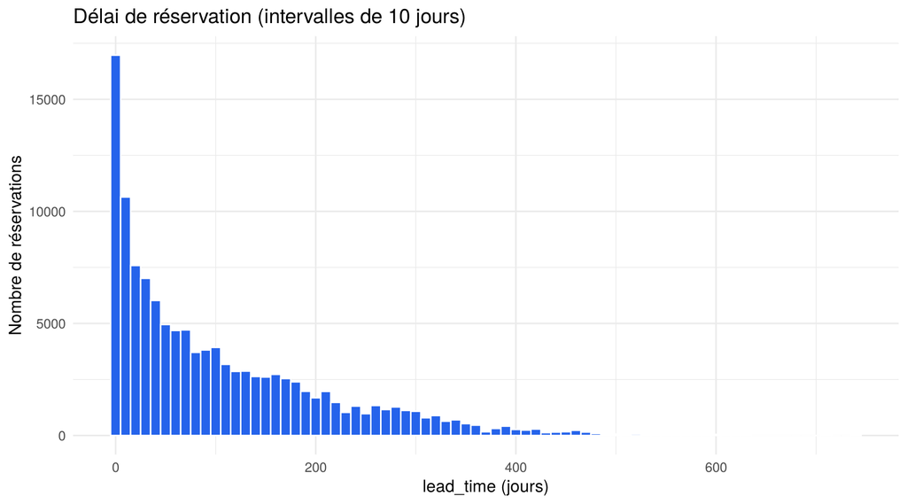

```r
ggplot(hotel, aes(x = lead_time)) +
  geom_histogram(binwidth = 10, fill = "#2563eb", colour = "white") +
  labs(title = "Délai de réservation (intervalles de 10 jours)",
       x = "lead_time (jours)", y = "Nombre de réservations")
```

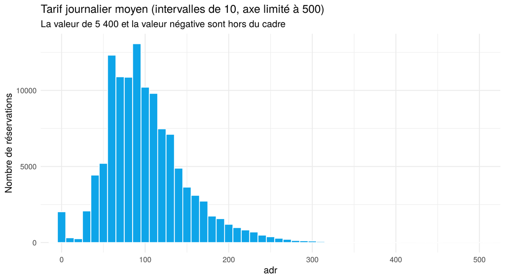

```r
ggplot(hotel, aes(x = adr)) +
  geom_histogram(binwidth = 10, fill = "#0ea5e9", colour = "white") +
  coord_cartesian(xlim = c(0, 500)) +
  labs(title = "Tarif journalier moyen (intervalles de 10, axe limité à 500)",
       subtitle = "La valeur de 5 400 et la valeur négative sont hors du cadre",
       x = "adr", y = "Nombre de réservations")
```

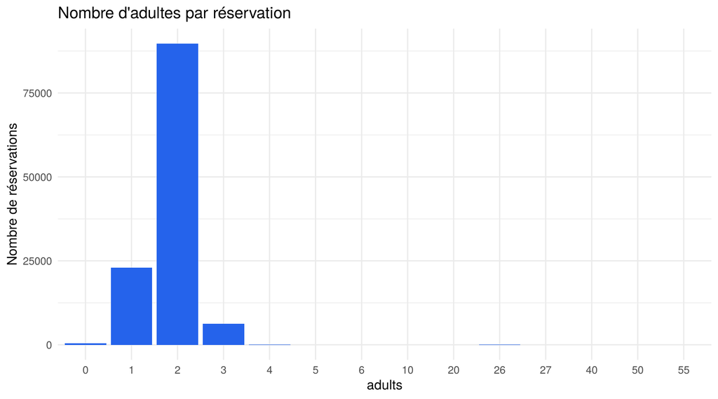

```r
ggplot(hotel, aes(x = factor(adults))) +
  geom_bar(fill = "#2563eb") +
  labs(title = "Nombre d'adultes par réservation", x = "adults", y = "Nombre de réservations")
```

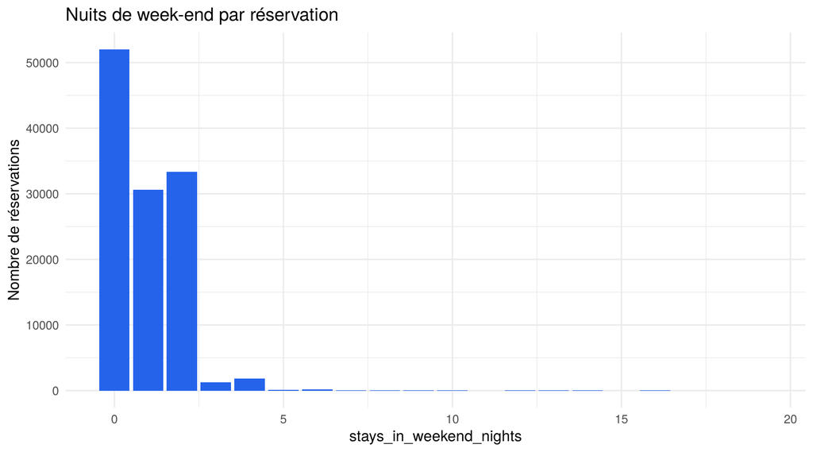

```r
ggplot(hotel, aes(x = stays_in_weekend_nights)) +
  geom_bar(fill = "#2563eb") +
  labs(title = "Nuits de week-end par réservation", x = "stays_in_weekend_nights", y = "Nombre de réservations")
```

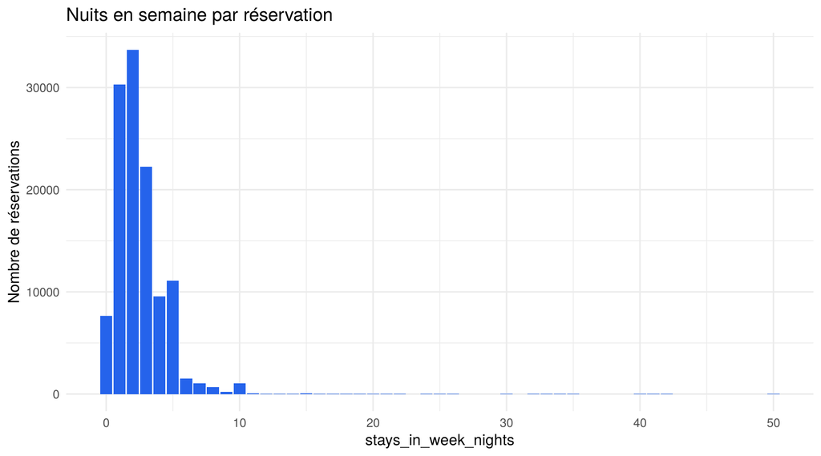

```r
ggplot(hotel, aes(x = stays_in_week_nights)) +
  geom_bar(fill = "#2563eb") +
  labs(title = "Nuits en semaine par réservation", x = "stays_in_week_nights", y = "Nombre de réservations")
```

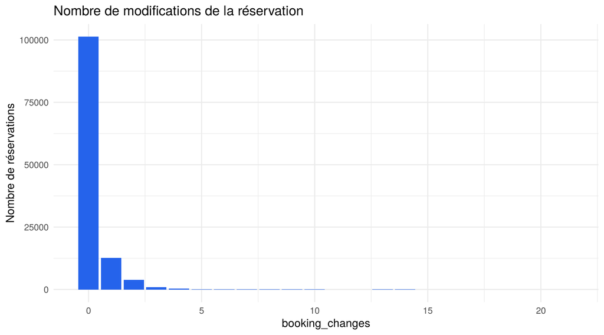

```r
ggplot(hotel, aes(x = booking_changes)) +
  geom_bar(fill = "#2563eb") +
  labs(title = "Nombre de modifications de la réservation", x = "booking_changes", y = "Nombre de réservations")
```

Les boîtes à moustaches résument les six variables sur un même graphique (un panneau par variable, chacun avec sa propre échelle).

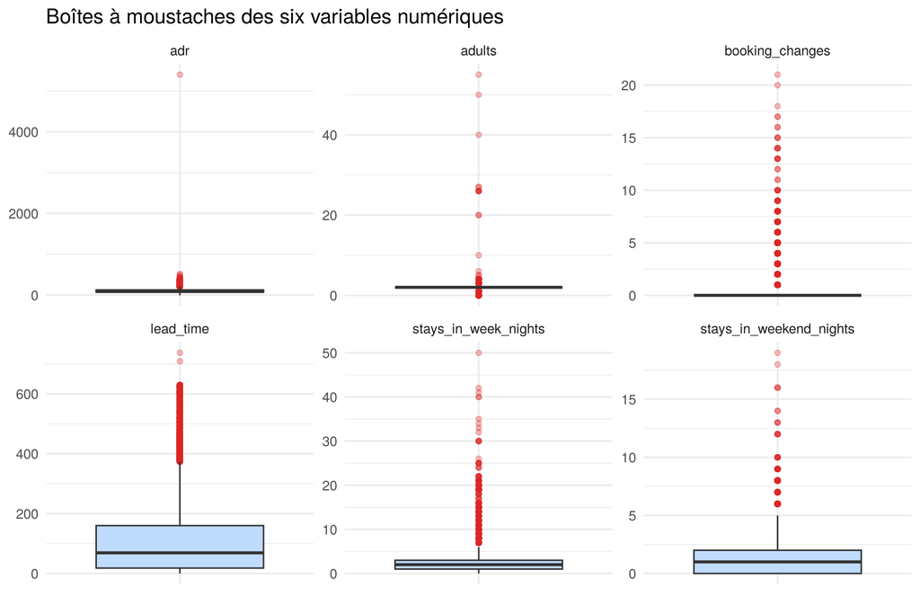

```r
hotel %>%
  select(all_of(vars_num)) %>%
  pivot_longer(everything(), names_to = "variable", values_to = "valeur") %>%
  ggplot(aes(x = "", y = valeur)) +
  geom_boxplot(fill = "#bfdbfe", outlier.colour = "#dc2626", outlier.alpha = 0.3) +
  facet_wrap(~ variable, scales = "free_y", ncol = 3) +
  labs(title = "Boîtes à moustaches des six variables numériques", x = NULL, y = NULL)
```

## 3.3 Description et interprétation

- **`lead_time` (délai de réservation)** : distribution fortement asymétrique à droite. La médiane (69 jours) est nettement inférieure à la moyenne (104.01 jours), tirée vers le haut par les réservations très anticipées (jusqu’à 737 jours). La moitié des réservations sont faites entre 18 et 160 jours à l’avance. 2.6 % des réservations sont faites plus d’un an à l’avance, ce qui correspond surtout à des réservations de groupes ou d’agences. Pour l’hôtel, cette grande dispersion signifie qu’une partie importante du carnet de réservations est connue longtemps à l’avance, donc exposée à un risque d’annulation pendant longtemps.
- **`adr` (tarif journalier moyen)** : distribution légèrement asymétrique, centrée autour d’une médiane de 94.575. Elle contient des valeurs à 0 (séjours offerts), une valeur négative et une valeur extrême de 5 400. Hors de ces cas, la plupart des tarifs se situent entre 69.29 et 126. La moyenne est peu affectée par la valeur de 5 400 grâce à la taille de l’échantillon, mais l’écart-type et le maximum le sont fortement.
- **`stays_in_weekend_nights` et `stays_in_week_nights`** : séjours courts. La médiane est de 1 nuit de week-end et 2 nuits en semaine ; 43.6 % des réservations ne comprennent aucune nuit de week-end. Les séjours de plusieurs semaines sont rares mais existent (jusqu’à 19 nuits de week-end et 50 nuits en semaine), probablement au Resort Hotel.
- **`adults`** : variable discrète très concentrée, 75.1 % des réservations concernent exactement 2 adultes (couples). Les valeurs 0 et celles supérieures à 4 sont rares ; quelques réservations de 20 à 55 adultes ressortent (groupes).
- **`booking_changes`** : 84.9 % des réservations ne sont jamais modifiées. La médiane et le troisième quartile valent 0, donc l’IQR vaut 0 : toute modification apparaît comme « atypique » par la méthode IQR, ce qui montre les limites de cette méthode sur une variable de comptage.

# Mission 4 : Analyse univariée des variables catégorielles

Cinq variables catégorielles sont retenues : `hotel`, `market_segment`, `deposit_type`, `customer_type` et `reservation_status`. La variable cible `is_canceled` est aussi décrite.

## 4.1 Effectifs et fréquences

Pour chaque variable, `count()` donne les effectifs et `mutate()` calcule le pourcentage.

```r
hotel %>% count(hotel, sort = TRUE) %>% mutate(pourcentage = round(100 * n / sum(n), 2))
```

| hotel | n | pourcentage |
| --- | --- | --- |
| City Hotel | 79330 | 66.45 |
| Resort Hotel | 40060 | 33.55 |

```r
hotel %>% count(is_canceled, sort = TRUE) %>% mutate(pourcentage = round(100 * n / sum(n), 2))
```

| is_canceled | n | pourcentage |
| --- | --- | --- |
| 0 | 75166 | 62.96 |
| 1 | 44224 | 37.04 |

```r
hotel %>% count(market_segment, sort = TRUE) %>% mutate(pourcentage = round(100 * n / sum(n), 2))
```

| market_segment | n | pourcentage |
| --- | --- | --- |
| Online TA | 56477 | 47.30 |
| Offline TA/TO | 24219 | 20.29 |
| Groups | 19811 | 16.59 |
| Direct | 12606 | 10.56 |
| Corporate | 5295 | 4.44 |
| Complementary | 743 | 0.62 |
| Aviation | 237 | 0.20 |
| Undefined | 2 | 0.00 |

```r
hotel %>% count(deposit_type, sort = TRUE) %>% mutate(pourcentage = round(100 * n / sum(n), 2))
```

| deposit_type | n | pourcentage |
| --- | --- | --- |
| No Deposit | 104641 | 87.65 |
| Non Refund | 14587 | 12.22 |
| Refundable | 162 | 0.14 |

```r
hotel %>% count(customer_type, sort = TRUE) %>% mutate(pourcentage = round(100 * n / sum(n), 2))
```

| customer_type | n | pourcentage |
| --- | --- | --- |
| Transient | 89613 | 75.06 |
| Transient-Party | 25124 | 21.04 |
| Contract | 4076 | 3.41 |
| Group | 577 | 0.48 |

```r
hotel %>% count(reservation_status, sort = TRUE) %>% mutate(pourcentage = round(100 * n / sum(n), 2))
```

| reservation_status | n | pourcentage |
| --- | --- | --- |
| Check-Out | 75166 | 62.96 |
| Canceled | 43017 | 36.03 |
| No-Show | 1207 | 1.01 |

## 4.2 Visualisations

Les cinq variables sont empilées avec `pivot_longer()`, puis `facet_wrap()` crée un panneau par variable.

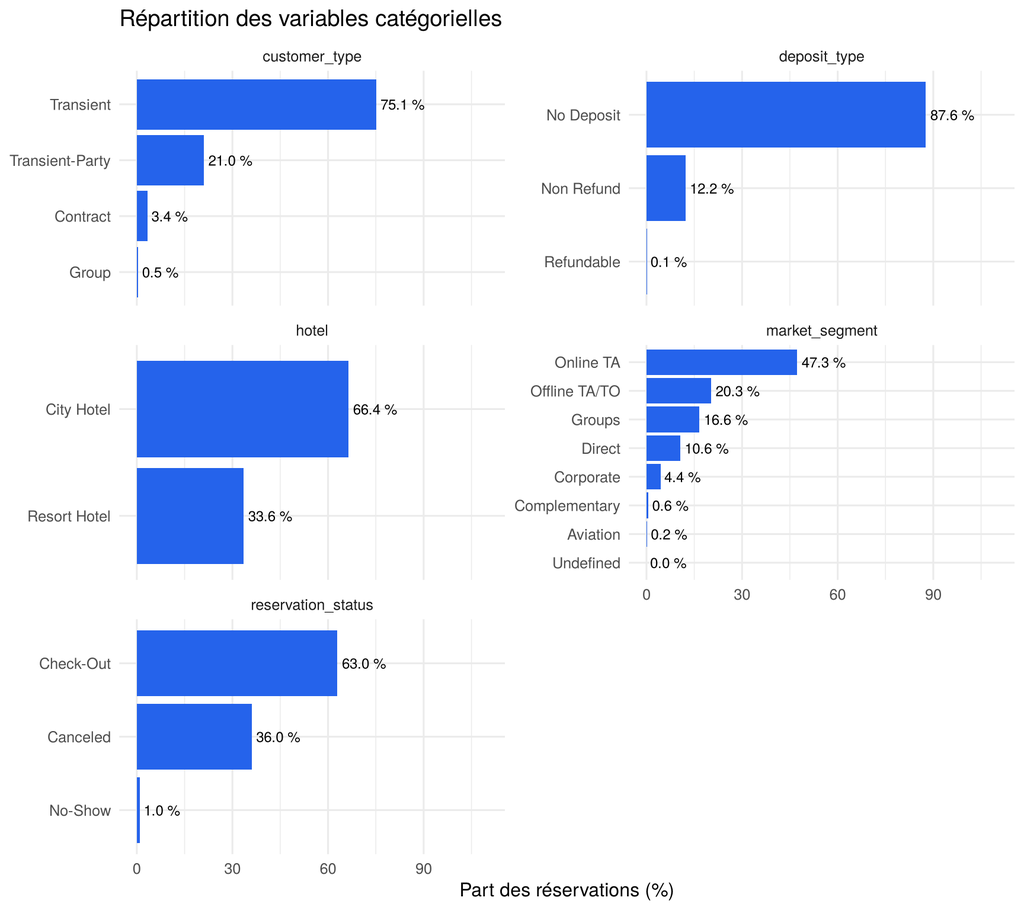

```r
hotel %>%
  select(hotel, market_segment, deposit_type, customer_type, reservation_status) %>%
  pivot_longer(everything(), names_to = "variable", values_to = "modalite") %>%
  count(variable, modalite) %>%
  group_by(variable) %>%
  mutate(pourcentage = 100 * n / sum(n)) %>%
  ggplot(aes(x = reorder(modalite, pourcentage), y = pourcentage)) +
  geom_col(fill = "#2563eb") +
  geom_text(aes(label = sprintf("%.1f %%", pourcentage)), hjust = -0.1, size = 3.2) +
  coord_flip() +
  facet_wrap(~ variable, scales = "free_y", ncol = 2) +
  ylim(0, 110) +
  labs(title = "Répartition des variables catégorielles", x = NULL, y = "Part des réservations (%)")
```

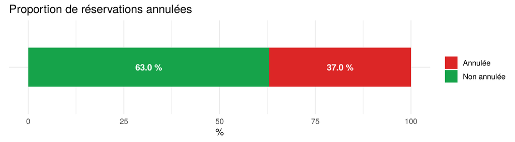

```r
hotel %>%
  mutate(statut = ifelse(is_canceled == 1, "Annulée", "Non annulée")) %>%
  count(statut) %>%
  mutate(pourcentage = 100 * n / sum(n)) %>%
  ggplot(aes(x = "", y = pourcentage, fill = statut)) +
  geom_col(width = 0.5) +
  geom_text(aes(label = sprintf("%.1f %%", pourcentage)), position = position_stack(vjust = 0.5),
            colour = "white", fontface = "bold") +
  coord_flip() +
  scale_fill_manual(values = couleurs_annul) +
  labs(title = "Proportion de réservations annulées", x = NULL, y = "%", fill = NULL)
```

## 4.3 Interprétation

- **`hotel`** : le City Hotel représente 66.4 % des réservations, soit environ deux fois plus que le Resort Hotel. Toute statistique globale est donc dominée par le City Hotel ; les comparaisons doivent se faire par hôtel.
- **`is_canceled`** : 37 % des réservations sont annulées. Ce taux est élevé et confirme l’importance de l’enjeu pour les deux établissements.
- **`market_segment`** : les agences de voyage en ligne (*Online TA*, 47.3 %) dominent, devant les agences hors ligne (*Offline TA/TO*, 20.3 %) et les groupes (16.6 %). Les réservations directes ne pèsent que 10.6 %. Les hôtels dépendent donc fortement des intermédiaires.
- **`deposit_type`** : 87.6 % des réservations sont faites sans dépôt. Les réservations non remboursables (*Non Refund*) représentent 12.2 %, et les dépôts remboursables sont presque inexistants (0.1 %).
- **`customer_type`** : la clientèle individuelle (*Transient*, 75.1 %) domine, suivie des individus liés à d’autres réservations (*Transient-Party*). Les contrats et groupes sont minoritaires.
- **`reservation_status`** : 63 % des séjours ont eu lieu (*Check-Out*), 36 % ont été annulés et 1 % sont des non-présentations. Les *No-Show* sont rares mais coûteux, car la chambre est restée vide sans préavis.

# Mission 5 : Analyse des données manquantes

## Partie A : Diagnostic

### A.1 Nombre et pourcentage de valeurs manquantes

```r
tab_na <- data.frame(
  Variable    = names(hotel),
  Manquants   = colSums(is.na(hotel)),
  Pourcentage = round(100 * colMeans(is.na(hotel)), 3),
  row.names = NULL
) %>%
  filter(Manquants > 0) %>%
  arrange(desc(Manquants))
tab_na
```

| Variable | Manquants | Pourcentage |
| --- | --- | --- |
| company | 112593 | 94.307 |
| agent | 16340 | 13.686 |
| country | 488 | 0.409 |
| children | 4 | 0.003 |

`company` est presque entièrement vide (94.307 %), `agent` l’est pour 13.686 % des lignes. `country` (488 lignes) et `children` (4 lignes) sont très peu touchées. Les 28 autres variables sont complètes.

### A.2 Visualisation de la répartition

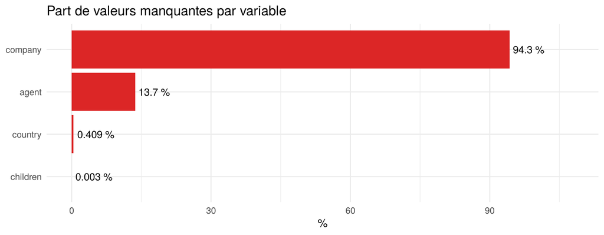

```r
ggplot(tab_na, aes(x = reorder(Variable, Pourcentage), y = Pourcentage)) +
  geom_col(fill = "#dc2626") +
  geom_text(aes(label = paste0(signif(Pourcentage, 3), " %")), hjust = -0.1) +
  coord_flip() +
  ylim(0, 108) +
  labs(title = "Part de valeurs manquantes par variable", x = NULL, y = "%")
```

### A.3 Combinaisons d’absences

```r
hotel %>%
  transmute(agent    = ifelse(is.na(agent), "manquant", "présent"),
            company  = ifelse(is.na(company), "manquant", "présent"),
            country  = ifelse(is.na(country), "manquant", "présent"),
            children = ifelse(is.na(children), "manquant", "présent")) %>%
  count(agent, company, country, children, name = "Effectif") %>%
  mutate(Pourcentage = round(100 * Effectif / sum(Effectif), 2)) %>%
  arrange(desc(Effectif))
```

| agent | company | country | children | Effectif | Pourcentage |
| --- | --- | --- | --- | --- | --- |
| présent | manquant | présent | présent | 102677 | 86.00 |
| manquant | manquant | présent | présent | 9598 | 8.04 |
| manquant | présent | présent | présent | 6406 | 5.37 |
| présent | présent | présent | présent | 217 | 0.18 |
| manquant | présent | manquant | présent | 174 | 0.15 |
| manquant | manquant | manquant | présent | 160 | 0.13 |
| présent | manquant | manquant | présent | 154 | 0.13 |
| manquant | manquant | présent | manquant | 2 | 0.00 |
| présent | manquant | présent | manquant | 2 | 0.00 |

Le motif le plus fréquent est « agent présent, company manquante ». Seule une petite part des réservations a à la fois un agent et une entreprise : ces deux intermédiaires sont le plus souvent mutuellement exclusifs.

### A.4 Les absences se concentrent-elles dans certains groupes ?

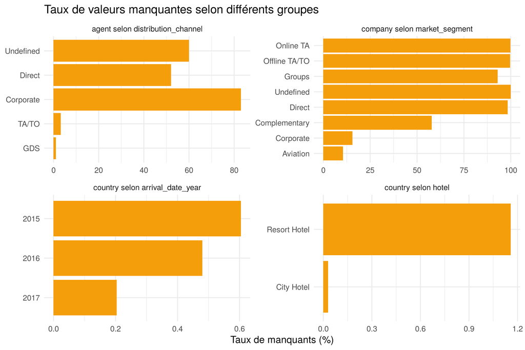

```r
na_groupes <- bind_rows(
  hotel %>% group_by(groupe = market_segment) %>%
    summarise(taux = 100 * mean(is.na(company))) %>% mutate(variable = "company selon market_segment"),
  hotel %>% group_by(groupe = distribution_channel) %>%
    summarise(taux = 100 * mean(is.na(agent))) %>% mutate(variable = "agent selon distribution_channel"),
  hotel %>% group_by(groupe = hotel) %>%
    summarise(taux = 100 * mean(is.na(country))) %>% mutate(variable = "country selon hotel"),
  hotel %>% group_by(groupe = as.character(arrival_date_year)) %>%
    summarise(taux = 100 * mean(is.na(country))) %>% mutate(variable = "country selon arrival_date_year")
)

ggplot(na_groupes, aes(x = reorder(groupe, taux), y = taux)) +
  geom_col(fill = "#f59e0b") +
  coord_flip() +
  facet_wrap(~ variable, scales = "free", ncol = 2) +
  labs(title = "Taux de valeurs manquantes selon différents groupes", x = NULL, y = "Taux de manquants (%)")
```

```r
# Les réservations sans pays se comportent-elles différemment ?
hotel %>%
  mutate(country_manquant = is.na(country)) %>%
  group_by(country_manquant) %>%
  summarise(n = n(), taux_annulation = round(mean(is_canceled), 3),
            part_resort = round(mean(hotel == "Resort Hotel"), 3))
```

| country_manquant | n | taux_annulation | part_resort |
| --- | --- | --- | --- |
| FALSE | 118902 | 0.371 | 0.333 |
| TRUE | 488 | 0.137 | 0.951 |

```r
# Les quatre lignes sans valeur pour children
hotel[is.na(hotel$children),
      c("hotel", "is_canceled", "adults", "babies", "arrival_date_year",
        "arrival_date_month", "market_segment")]
```

|  | hotel | is_canceled | adults | babies | arrival_date_year | arrival_date_month | market_segment |
| --- | --- | --- | --- | --- | --- | --- | --- |
| 40601 | City Hotel | 1 | 2 | 0 | 2015 | August | Undefined |
| 40668 | City Hotel | 1 | 2 | 0 | 2015 | August | Direct |
| 40680 | City Hotel | 1 | 3 | 0 | 2015 | August | Undefined |
| 41161 | City Hotel | 1 | 2 | 0 | 2015 | August | Online TA |

Les absences ne sont pas réparties au hasard :

- `company` est quasi toujours vide pour les segments *Online TA*, *Offline TA/TO* et *Direct*, et beaucoup moins pour *Corporate* et *Aviation*. L’absence suit donc le type de client.
- `agent` est surtout manquant pour les canaux *Corporate* et *Direct*, et presque jamais pour *TA/TO* : une réservation directe n’a logiquement pas d’agent.
- `country` manque surtout au Resort Hotel, et les réservations sans pays ont un taux d’annulation bien plus faible que les autres.
- Les quatre valeurs manquantes de `children` concernent toutes le City Hotel, en août 2015, et des réservations annulées.

## Partie B : Mécanismes d’absence

**Rappel des trois mécanismes :**

- **MCAR** (*Missing Completely At Random*) : la probabilité d’absence ne dépend ni des variables observées ni de la valeur manquante elle-même. Les cas complets restent alors un échantillon représentatif.
- **MAR** (*Missing At Random*) : l’absence dépend d’autres variables observées, mais pas de la valeur manquante une fois ces variables prises en compte.
- **MNAR** (*Missing Not At Random*) : l’absence dépend de la valeur manquante elle-même, ou d’une information non observée.

**Hypothèses argumentées pour nos données :**

[output not shown]

Ces mécanismes ne peuvent pas être démontrés à partir des seules données : les tableaux ci-dessus montrent que l’absence est **associée** à des variables observées (ce qui écarte le MCAR pour `company`, `agent` et `country`), mais aucun test ne permet d’écarter définitivement le MNAR.

## Partie C : Stratégies de traitement

### C.1 Cas de `agent` et `company` : pas d’imputation

Remplacer un identifiant manquant par une moyenne, une médiane ou un mode reviendrait à **inventer un agent ou une entreprise** qui n’a jamais été associé à la réservation, et la moyenne d’identifiants n’a aucun sens. Supprimer les lignes concernées ferait perdre 94.3 % du jeu pour `company`. La stratégie retenue est donc :

- recoder l’absence en une modalité explicite `"Aucun"` (l’identifiant devient une variable catégorielle) ;
- créer deux indicateurs `has_agent` et `has_company` (0/1), plus faciles à exploiter.

### C.2 Cas de `children` : suppression contre imputation par la médiane

```r
# Stratégie 1 : suppression des 4 lignes
s1 <- hotel %>% filter(!is.na(children))
# Stratégie 2 : imputation par la médiane (égale au mode, 0)
med_children <- median(hotel$children, na.rm = TRUE)
s2 <- hotel %>% mutate(children = ifelse(is.na(children), med_children, children))

data.frame(
  Version    = c("Avant (NA exclus)", "Suppression", "Imputation médiane"),
  Effectif   = c(sum(!is.na(hotel$children)), nrow(s1), nrow(s2)),
  Manquants  = c(sum(is.na(hotel$children)), sum(is.na(s1$children)), sum(is.na(s2$children))),
  Moyenne    = round(c(mean(hotel$children, na.rm = TRUE), mean(s1$children), mean(s2$children)), 4),
  Mediane    = c(median(hotel$children, na.rm = TRUE), median(s1$children), median(s2$children)),
  Ecart_type = round(c(sd(hotel$children, na.rm = TRUE), sd(s1$children), sd(s2$children)), 4)
)
```

| Version | Effectif | Manquants | Moyenne | Mediane | Ecart_type |
| --- | --- | --- | --- | --- | --- |
| Avant (NA exclus) | 119386 | 4 | 0.1039 | 0 | 0.3986 |
| Suppression | 119386 | 0 | 0.1039 | 0 | 0.3986 |
| Imputation médiane | 119390 | 0 | 0.1039 | 0 | 0.3986 |

```r
c(taux_annulation_avant       = mean(hotel$is_canceled),
  taux_annulation_suppression = mean(s1$is_canceled),
  taux_annulation_imputation  = mean(s2$is_canceled))
```

```
##       taux_annulation_avant taux_annulation_suppression
##                   0.3704163                   0.3703952
##  taux_annulation_imputation
##                   0.3704163
```

- **Suppression** : simple et sans hypothèse, valable si l’absence est MCAR. Elle retire 4 réservations, toutes annulées : l’effet sur le taux d’annulation est négligeable.
- **Imputation par la médiane (0)** : conserve toutes les lignes. La médiane et le mode valent 0, valeur observée dans 92.8 % des cas ; la moyenne est inchangée à l’arrondi (l’écart apparaît seulement à la sixième décimale).
- **Décision** : **imputation par la médiane (0)**. Les deux stratégies donnent des distributions identiques à l’arrondi près ; l’imputation garde toutes les réservations et la valeur 0 est de loin la plus probable (une réservation avec enfant aurait plus probablement été saisie avec soin).

### C.3 Cas de `country` : suppression contre modalité « Inconnu »

```r
# Stratégie 1 : suppression des lignes sans pays
c1 <- hotel %>% filter(!is.na(country))
# Stratégie 2 : modalité explicite "Inconnu"
c2 <- hotel %>% mutate(country = ifelse(is.na(country), "Inconnu", country))
# Stratégie 3 (pour comparaison) : imputation par le mode
tab_pays <- hotel %>% filter(!is.na(country)) %>% count(country, sort = TRUE)
mode_country <- tab_pays$country[1]
c3 <- hotel %>% mutate(country = ifelse(is.na(country), mode_country, country))

data.frame(
  Strategie        = c("Avant", "Suppression", "Modalité 'Inconnu'", paste0("Mode (", mode_country, ")")),
  Observations     = c(nrow(hotel), nrow(c1), nrow(c2), nrow(c3)),
  Part_Resort      = round(c(mean(hotel$hotel == "Resort Hotel"), mean(c1$hotel == "Resort Hotel"),
                             mean(c2$hotel == "Resort Hotel"), mean(c3$hotel == "Resort Hotel")), 4),
  Taux_annulation  = round(c(mean(hotel$is_canceled), mean(c1$is_canceled),
                             mean(c2$is_canceled), mean(c3$is_canceled)), 4),
  Part_pays_mode   = round(c(mean(hotel$country == mode_country, na.rm = TRUE),
                             mean(c1$country == mode_country), mean(c2$country == mode_country),
                             mean(c3$country == mode_country)), 4)
)
```

| Strategie | Observations | Part_Resort | Taux_annulation | Part_pays_mode |
| --- | --- | --- | --- | --- |
| Avant | 119390 | 0.3355 | 0.3704 | 0.4087 |
| Suppression | 118902 | 0.3330 | 0.3714 | 0.4087 |
| Modalité ‘Inconnu’ | 119390 | 0.3355 | 0.3704 | 0.4070 |
| Mode (PRT) | 119390 | 0.3355 | 0.3704 | 0.4111 |

- **Suppression** : elle retire des réservations qui ne sont pas représentatives (surtout Resort Hotel, peu annulées). Elle **biaise** légèrement le taux d’annulation vers le haut et sous-représente le Resort Hotel.
- **Imputation par le mode (PRT)** : elle attribue artificiellement 488 réservations au pays dominant, ce qui gonfle sa part sans fondement.
- **Modalité « Inconnu »** : elle conserve toutes les lignes, n’invente aucune information et permet de suivre ce groupe à part.
- **Décision** : **modalité « Inconnu »**, car l’absence n’est pas MCAR et les deux autres stratégies introduisent un biais.

### C.4 Récapitulatif des décisions

| Variable | Manquants | Mécanisme plausible | Traitement retenu |
| --- | --- | --- | --- |
| `company` | 112593 | Structurel (non applicable) | Modalité « Aucun » + indicateur `has_company` |
| `agent` | 16340 | Structurel (non applicable) | Modalité « Aucun » + indicateur `has_agent` |
| `country` | 488 | MAR, MNAR possible | Modalité « Inconnu » |
| `children` | 4 | Plausiblement MCAR | Imputation par la médiane (0) |

# Mission 6 : Identification et analyse des valeurs aberrantes

Quatre variables numériques sont examinées : `lead_time`, `adr`, `adults` et la durée totale du séjour `total_nights` (nuits de week-end + nuits de semaine).

## 6.1 Boîtes à moustaches

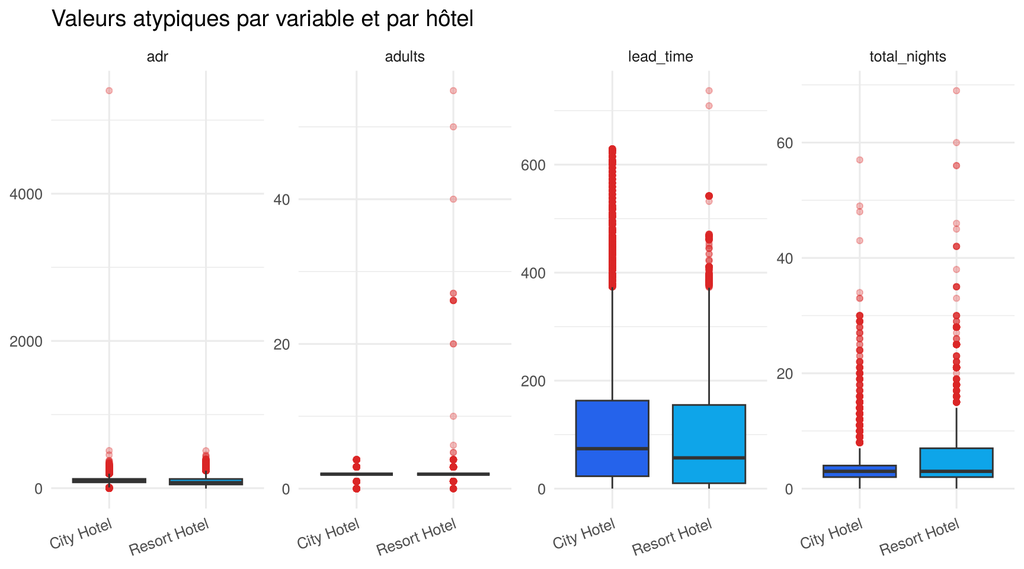

```r
hotel_out <- hotel %>%
  mutate(total_nights = stays_in_weekend_nights + stays_in_week_nights)

vars_out <- c("lead_time", "adr", "adults", "total_nights")

hotel_out %>%
  select(hotel, all_of(vars_out)) %>%
  pivot_longer(-hotel, names_to = "variable", values_to = "valeur") %>%
  ggplot(aes(x = hotel, y = valeur, fill = hotel)) +
  geom_boxplot(outlier.alpha = 0.3, outlier.colour = "#dc2626") +
  facet_wrap(~ variable, scales = "free_y", ncol = 4) +
  scale_fill_manual(values = couleurs_hotel, guide = "none") +
  labs(title = "Valeurs atypiques par variable et par hôtel", x = NULL, y = NULL) +
  theme(axis.text.x = element_text(angle = 20, hjust = 1))
```

## 6.2 Détection par la méthode de l’écart interquartile

Une observation est déclarée atypique si elle se situe en dehors de l’intervalle [Q1 - 1,5 × IQR ; Q3 + 1,5 × IQR].

```r
detection <- hotel_out %>%
  select(all_of(vars_out)) %>%
  pivot_longer(everything(), names_to = "variable", values_to = "valeur") %>%
  group_by(variable) %>%
  summarise(
    Q1          = quantile(valeur, 0.25),
    Q3          = quantile(valeur, 0.75),
    IQR         = IQR(valeur),
    borne_inf   = Q1 - 1.5 * IQR,
    borne_sup   = Q3 + 1.5 * IQR,
    atypiques   = sum(valeur < borne_inf | valeur > borne_sup),
    pourcentage = round(100 * atypiques / n(), 2)
  )
detection
```

| variable | Q1 | Q3 | IQR | borne_inf | borne_sup | atypiques | pourcentage |
| --- | --- | --- | --- | --- | --- | --- | --- |
| adr | 69.29 | 126 | 56.71 | -15.775 | 211.065 | 3793 | 3.18 |
| adults | 2.00 | 2 | 0.00 | 2.000 | 2.000 | 29710 | 24.88 |
| lead_time | 18.00 | 160 | 142.00 | -195.000 | 373.000 | 3005 | 2.52 |
| total_nights | 2.00 | 4 | 2.00 | -1.000 | 7.000 | 5257 | 4.40 |

## 6.3 Examen des atypiques dans leur contexte métier

```r
# lead_time : borne supérieure de Tukey, puis segments des réservations au-delà
lt_q1  <- quantile(hotel_out$lead_time, 0.25)
lt_q3  <- quantile(hotel_out$lead_time, 0.75)
lt_sup <- lt_q3 + 1.5 * IQR(hotel_out$lead_time)
hotel_out %>%
  filter(lead_time > lt_sup) %>%
  count(market_segment, sort = TRUE) %>%
  mutate(pct = round(100 * n / sum(n), 1))
```

| market_segment | n | pct |
| --- | --- | --- |
| Groups | 2022 | 67.3 |
| Offline TA/TO | 967 | 32.2 |
| Online TA | 10 | 0.3 |
| Direct | 5 | 0.2 |
| Complementary | 1 | 0.0 |

```r
# adr : les 5 tarifs les plus élevés et les tarifs négatifs
hotel_out %>% arrange(desc(adr)) %>%
  select(hotel, adr, adults, children, total_nights, reserved_room_type, market_segment) %>% head(5)
```

| hotel | adr | adults | children | total_nights | reserved_room_type | market_segment |
| --- | --- | --- | --- | --- | --- | --- |
| City Hotel | 5400.0 | 2 | 0 | 1 | A | Offline TA/TO |
| City Hotel | 510.0 | 1 | 0 | 1 | A | Offline TA/TO |
| Resort Hotel | 508.0 | 2 | 0 | 1 | A | Corporate |
| City Hotel | 451.5 | 2 | 2 | 2 | E | Direct |
| Resort Hotel | 450.0 | 2 | 0 | 14 | A | Online TA |

```r
hotel_out %>% filter(adr < 0) %>%
  select(hotel, adr, adults, total_nights, market_segment)
```

| hotel | adr | adults | total_nights | market_segment |
| --- | --- | --- | --- | --- |
| Resort Hotel | -6.38 | 2 | 10 | Groups |

```r
# adults : réservations de 10 adultes ou plus
hotel_out %>% filter(adults >= 10) %>%
  count(hotel, adults, market_segment, is_canceled, adr)
```

| hotel | adults | market_segment | is_canceled | adr | n |
| --- | --- | --- | --- | --- | --- |
| Resort Hotel | 10 | Direct | 1 | 0 | 1 |
| Resort Hotel | 20 | Direct | 1 | 0 | 2 |
| Resort Hotel | 26 | Offline TA/TO | 1 | 0 | 5 |
| Resort Hotel | 27 | Direct | 1 | 0 | 2 |
| Resort Hotel | 40 | Direct | 1 | 0 | 1 |
| Resort Hotel | 50 | Direct | 1 | 0 | 1 |
| Resort Hotel | 55 | Direct | 1 | 0 | 1 |

```r
# total_nights : séjours de plus de 3 semaines
hotel_out %>% filter(total_nights > 21) %>%
  count(hotel, customer_type) %>% arrange(desc(n))
```

| hotel | customer_type | n |
| --- | --- | --- |
| Resort Hotel | Transient | 56 |
| City Hotel | Transient | 50 |
| Resort Hotel | Transient-Party | 43 |
| Resort Hotel | Contract | 9 |
| City Hotel | Transient-Party | 3 |
| City Hotel | Contract | 1 |

## 6.4 Tableau récapitulatif des décisions

| Variable | Méthode | Atypiques (IQR) | Caractéristiques | Décision | Justification |
| --- | --- | --- | --- | --- | --- |
| `lead_time` | Boxplot + IQR | 3005 (2.52 %) | Groupes et agences hors ligne | **Conserver** | Comportement réel de réservation anticipée |
| `adr` | Boxplot + IQR + examen | 3793 (3.18 %) | Grandes chambres, haute saison ; 1 valeur à 5 400 ; 1 valeur négative | **Conserver**, sauf **exclure** les 2 lignes erronées | 5 400 et -6,38 sont des erreurs manifestes ; les autres sont plausibles |
| `adults` | Boxplot + IQR + examen | 29710 (24.88 %) | IQR nul ; groupes de 10 à 55 adultes annulés | **Conserver** (signaler les groupes) | Valeurs rares mais possibles ; les réservations à 0 occupant sont traitées comme incohérences (mission 7) |
| `total_nights` | Boxplot + IQR | 5257 (4.4 %) | Longs séjours au Resort Hotel | **Conserver** | Séjours saisonniers plausibles |

# Mission 7 : Nettoyage et préparation des données

Toutes les opérations partent d’une copie ; `hotel_raw` reste intact. Après chaque étape, le nombre de lignes est noté (`n_0`, `n_1`…) pour construire le journal des opérations à la fin de la mission.

```r
clean <- hotel_raw
n_0 <- nrow(clean)
```

## 7.1 Doublons

```r
avec_dup <- mean(clean$is_canceled)
sans_dup <- mean(clean$is_canceled[!duplicated(clean)])
round(c(taux_annulation_avec_doublons = avec_dup, taux_annulation_sans_doublons = sans_dup), 4)
```

```
## taux_annulation_avec_doublons taux_annulation_sans_doublons
##                        0.3704                        0.2749
```

```r
# Les doublons sont-ils surtout des réservations de groupe ou d'agence ?
clean %>% filter(duplicated(clean)) %>% count(market_segment, sort = TRUE) %>%
  mutate(pct = round(100 * n / sum(n), 1))
```

| market_segment | n | pct |
| --- | --- | --- |
| Groups | 14869 | 46.5 |
| Offline TA/TO | 10330 | 32.3 |
| Online TA | 4859 | 15.2 |
| Corporate | 1083 | 3.4 |
| Direct | 802 | 2.5 |
| Complementary | 41 | 0.1 |
| Aviation | 10 | 0.0 |

**Décision : les doublons sont conservés.** Le jeu ne contient pas d’identifiant de réservation ni de numéro de chambre ; des lignes identiques peuvent donc correspondre à plusieurs chambres d’un même groupe ou d’une même agence, réservées le même jour aux mêmes conditions (les doublons proviennent majoritairement des segments de groupes et d’agences). Les supprimer ferait passer le taux d’annulation de 37 % à 27.5 %, en effaçant de vraies réservations. Cette limite est signalée dans la synthèse, et une variable `is_duplicate` est créée pour permettre une analyse de sensibilité.

```r
clean$is_duplicate <- as.integer(duplicated(clean))
n_1 <- nrow(clean)
```

## 7.2 Incohérences et valeurs aberrantes manifestes

```r
# a) Tarif négatif et tarif de 5 400 : erreurs manifestes, exclues
clean <- clean %>% filter(adr >= 0, adr < 5000)
n_2a <- nrow(clean)

# b) Réservations sans aucun occupant : impossibles, exclues
clean <- clean %>%
  filter(adults + ifelse(is.na(children), 0, children) + babies > 0)
n_2b <- nrow(clean)

# c) Valeurs isolées (9 ou 10 bébés/enfants pour 1 ou 2 adultes) : erreurs de saisie, exclues
#    Seuils = maximum observé hors valeurs isolées (3 enfants, 2 bébés), voir mission 2.7
clean <- clean %>% filter(babies <= 2, is.na(children) | children <= 3)
n_2c <- nrow(clean)
```

Les tarifs nuls, les séjours de 0 nuit, les réservations sans adulte (mais avec enfants) et les grands groupes sont **conservés** : ce sont des situations rares mais possibles. Ils sont repérables grâce aux nouvelles variables créées plus bas.

## 7.3 Données manquantes

```r
clean <- clean %>%
  mutate(
    children    = ifelse(is.na(children), 0, children),          # médiane
    country     = ifelse(is.na(country), "Inconnu", country),    # modalité explicite
    has_agent   = as.integer(!is.na(agent)),
    has_company = as.integer(!is.na(company)),
    agent       = ifelse(is.na(agent), "Aucun", as.character(agent)),
    company     = ifelse(is.na(company), "Aucun", as.character(company))
  )
n_3 <- nrow(clean)
sum(is.na(clean))
```

```
## [1] 0
```

## 7.4 Harmonisation des catégories

```r
clean <- clean %>%
  mutate(
    meal = ifelse(meal == "Undefined", "SC", meal),   # Undefined = SC selon l'article source
    market_segment       = ifelse(market_segment == "Undefined", "Inconnu", market_segment),
    distribution_channel = ifelse(distribution_channel == "Undefined", "Inconnu", distribution_channel)
  )
n_4 <- nrow(clean)
table(clean$meal)
```

```
##
##    BB    FB    HB    SC
## 92231   798 14458 11718
```

## 7.5 Correction des types

```r
mois_ordre <- c("January", "February", "March", "April", "May", "June", "July",
                "August", "September", "October", "November", "December")

clean <- clean %>%
  mutate(
    children                = as.integer(children),
    arrival_date_month      = factor(arrival_date_month, levels = mois_ordre),
    reservation_status_date = as.Date(reservation_status_date),
    across(c(hotel, meal, country, market_segment, distribution_channel,
             reserved_room_type, assigned_room_type, deposit_type,
             customer_type, reservation_status, agent, company), as.factor)
  )
n_5 <- nrow(clean)
```

`is_canceled` et `is_repeated_guest` restent codées 0/1 dans le fichier exporté (format pratique pour calculer des taux), et une version étiquetée `statut_annulation` est ajoutée pour les graphiques.

## 7.6 Nouvelles variables

```r
clean <- clean %>%
  mutate(
    total_nights      = stays_in_weekend_nights + stays_in_week_nights,
    total_guests      = adults + children + babies,
    has_children      = as.integer(children + babies > 0),
    arrival_date      = as.Date(paste(arrival_date_year, as.integer(arrival_date_month),
                                      arrival_date_day_of_month, sep = "-")),
    season            = factor(case_when(
                          arrival_date_month %in% c("December", "January", "February") ~ "Hiver",
                          arrival_date_month %in% c("March", "April", "May")           ~ "Printemps",
                          arrival_date_month %in% c("June", "July", "August")          ~ "Été",
                          TRUE                                                          ~ "Automne"),
                          levels = c("Hiver", "Printemps", "Été", "Automne")),
    room_changed      = as.integer(as.character(reserved_room_type) != as.character(assigned_room_type)),
    lead_time_class   = cut(lead_time, breaks = c(-1, 7, 30, 90, 180, Inf),
                            labels = c("0-7 j", "8-30 j", "31-90 j", "91-180 j", "> 180 j")),
    statut_annulation = factor(ifelse(is_canceled == 1, "Annulée", "Non annulée"),
                               levels = c("Non annulée", "Annulée"))
  )
n_6 <- nrow(clean)
```

| Nouvelle variable | Définition | Utilité |
| --- | --- | --- |
| `total_nights` | Nuits de week-end + nuits de semaine | Durée réelle du séjour |
| `total_guests` | Adultes + enfants + bébés | Taille de la réservation |
| `has_children` | 1 si au moins un enfant ou bébé | Repérer les familles |
| `arrival_date` | Date d’arrivée complète | Analyses temporelles |
| `season` | Saison d’arrivée | Effet saisonnier |
| `room_changed` | 1 si la chambre attribuée diffère de celle réservée | Qualité de service |
| `lead_time_class` | Délai découpé en 5 classes | Lecture métier du délai |
| `has_agent`, `has_company` | Présence d’un agent ou d’une entreprise | Remplace des identifiants peu exploitables |
| `is_duplicate` | 1 si la ligne est identique à une précédente | Analyse de sensibilité |
| `statut_annulation` | Version étiquetée de `is_canceled` | Graphiques |

## 7.7 Comparaison avant / après et export

```r
# Journal des opérations
journal <- data.frame(
  Etape = c("0", "1", "2a", "2b", "2c", "3", "4", "5", "6"),
  Operation = c("Jeu original",
                "Doublons conservés, indicateur is_duplicate créé",
                "Exclusion du tarif négatif et du tarif de 5 400",
                "Exclusion des réservations sans occupant",
                "Exclusion des valeurs isolées de bébés/enfants (9 ou 10)",
                "Traitement des valeurs manquantes (children, country, agent, company)",
                "Harmonisation : meal Undefined -> SC ; Undefined -> Inconnu",
                "Correction des types (facteurs, mois ordonnés, date)",
                "Création de 8 nouvelles variables"),
  Lignes_apres = c(n_0, n_1, n_2a, n_2b, n_2c, n_3, n_4, n_5, n_6)
)
journal
```

| Etape | Operation | Lignes_apres |
| --- | --- | --- |
| 0 | Jeu original | 119390 |
| 1 | Doublons conservés, indicateur is_duplicate créé | 119390 |
| 2a | Exclusion du tarif négatif et du tarif de 5 400 | 119388 |
| 2b | Exclusion des réservations sans occupant | 119208 |
| 2c | Exclusion des valeurs isolées de bébés/enfants (9 ou 10) | 119205 |
| 3 | Traitement des valeurs manquantes (children, country, agent, company) | 119205 |
| 4 | Harmonisation : meal Undefined -> SC ; Undefined -> Inconnu | 119205 |
| 5 | Correction des types (facteurs, mois ordonnés, date) | 119205 |
| 6 | Création de 8 nouvelles variables | 119205 |

```r
# Comparaison avant / après

data.frame(
  Indicateur = c("Observations", "Variables", "Valeurs manquantes", "Taux d'annulation",
                 "adr moyen", "adr max", "adr min"),
  Avant = c(nrow(hotel_raw), ncol(hotel_raw), sum(is.na(hotel_raw)),
            round(mean(hotel_raw$is_canceled), 4), round(mean(hotel_raw$adr), 2),
            max(hotel_raw$adr), min(hotel_raw$adr)),
  Apres = c(nrow(clean), ncol(clean), sum(is.na(clean)),
            round(mean(clean$is_canceled), 4), round(mean(clean$adr), 2),
            max(clean$adr), min(clean$adr))
)
```

| Indicateur | Avant | Apres |
| --- | --- | --- |
| Observations | 119390.0000 | 119205.0000 |
| Variables | 32.0000 | 43.0000 |
| Valeurs manquantes | 129425.0000 | 0.0000 |
| Taux d’annulation | 0.3704 | 0.3708 |
| adr moyen | 101.8300 | 101.9300 |
| adr max | 5400.0000 | 510.0000 |
| adr min | -6.3800 | 0.0000 |

Le nettoyage retire seulement **185 lignes** (0.15 %), toutes justifiées comme erreurs manifestes. Le taux d’annulation est pratiquement inchangé, ce qui montre que le nettoyage n’a pas biaisé la variable d’intérêt.

```r
# Export du jeu préparé ; le fichier original n'est pas modifié
write.csv(clean, "data/hotel_bookings_clean.csv", row.names = FALSE)
file.exists("data/hotel_bookings_clean.csv")
```

```
## [1] TRUE
```

# Mission 8 : Analyse bivariée

Toutes les analyses portent sur le jeu préparé `clean`.

## Partie A : Numérique - Numérique

**Question (Q5) : le délai de réservation (`lead_time`) est-il lié au tarif journalier moyen (`adr`) ?**

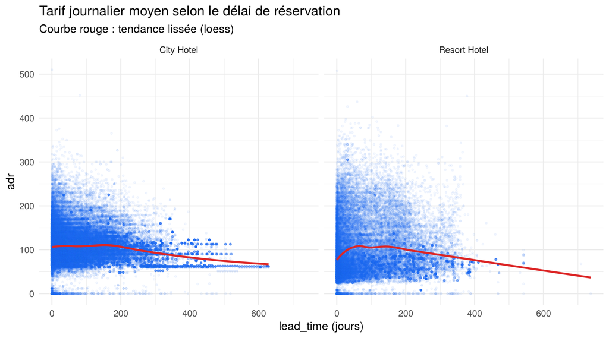

```r
ggplot(clean, aes(x = lead_time, y = adr)) +
  geom_point(alpha = 0.05, colour = "#2563eb", size = 0.7) +
  geom_smooth(method = "loess", colour = "#dc2626", se = FALSE) +
  facet_wrap(~ hotel) +
  labs(title = "Tarif journalier moyen selon le délai de réservation",
       subtitle = "Courbe rouge : tendance lissée (loess)",
       x = "lead_time (jours)", y = "adr")
```

Les deux variables sont fortement asymétriques et la relation n’est pas linéaire : la **corrélation de Spearman**, fondée sur les rangs, est plus adaptée que celle de Pearson. Les deux sont calculées pour comparaison.

```r
cor_spearman <- cor.test(clean$lead_time, clean$adr, method = "spearman", exact = FALSE)
cor_pearson  <- cor(clean$lead_time, clean$adr, method = "pearson")
cor_spearman
```

```
##
##  Spearman's rank correlation rho
##
## data:  clean$lead_time and clean$adr
## S = 2.7873e+14, p-value = 1.183e-05
## alternative hypothesis: true rho is not equal to 0
## sample estimates:
##        rho
## 0.01268771
```

```r
# Par hôtel
clean %>% group_by(hotel) %>%
  summarise(spearman = round(cor(lead_time, adr, method = "spearman"), 3),
            pearson  = round(cor(lead_time, adr, method = "pearson"), 3))
```

| hotel | spearman | pearson |
| --- | --- | --- |
| City Hotel | -0.104 | -0.155 |
| Resort Hotel | 0.157 | 0.030 |

**Interprétation.** Sur l’ensemble des réservations, le coefficient de Spearman vaut **ρ = 0.013** (Pearson : -0.068). La p-value est très faible, mais avec plus de 119 000 observations même une relation minuscule est « significative » : c’est l’intensité qui compte, et elle est **quasi nulle**.

## Partie B : Numérique - Catégorielle

### B.1 Délai de réservation selon le statut d’annulation (Q2)

```r
clean %>% group_by(statut_annulation) %>%
  summarise(n = n(), moyenne = round(mean(lead_time), 1), mediane = median(lead_time),
            Q1 = quantile(lead_time, 0.25), Q3 = quantile(lead_time, 0.75), ecart_type = round(sd(lead_time), 1))
```

| statut_annulation | n | moyenne | mediane | Q1 | Q3 | ecart_type |
| --- | --- | --- | --- | --- | --- | --- |
| Non annulée | 75008 | 80.1 | 45 | 9 | 124 | 91.1 |
| Annulée | 44197 | 144.9 | 113 | 49 | 214 | 118.6 |

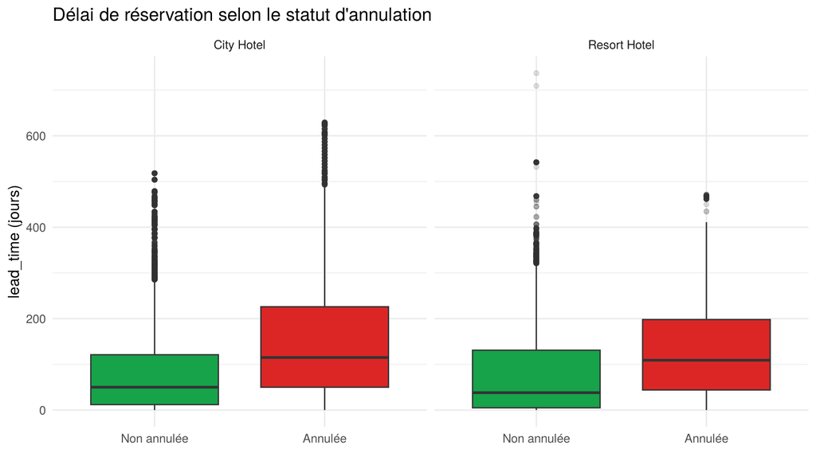

```r
ggplot(clean, aes(x = statut_annulation, y = lead_time, fill = statut_annulation)) +
  geom_boxplot(outlier.alpha = 0.15) +
  scale_fill_manual(values = couleurs_annul, guide = "none") +
  facet_wrap(~ hotel) +
  labs(title = "Délai de réservation selon le statut d'annulation", x = NULL, y = "lead_time (jours)")
```

```r
test_b1 <- wilcox.test(lead_time ~ statut_annulation, data = clean)
test_b1
```

```
##
##  Wilcoxon rank sum test with continuity correction
##
## data:  lead_time by statut_annulation
## W = 1030613525, p-value < 2.2e-16
## alternative hypothesis: true location shift is not equal to 0
```

Les distributions sont très asymétriques : on compare les **médianes** et on utilise le **test de Wilcoxon-Mann-Whitney** (non paramétrique) plutôt qu’un test t. Le délai médian est de **113 jours** pour les réservations annulées contre **45 jours** pour les non annulées. Le test rejette l’hypothèse de distributions identiques (p < 0,001) et l’écart est visible sur les boîtes dans les deux hôtels. **Interprétation métier** : plus une réservation est faite tôt, plus elle reste longtemps exposée à un changement de plans ; les réservations très anticipées méritent une politique de confirmation ou de dépôt.

### B.2 Tarif journalier moyen selon le type d’hôtel et le type de clientèle (Q4)

```r
clean %>% group_by(hotel) %>%
  summarise(n = n(), moyenne = round(mean(adr), 2), mediane = median(adr),
            Q1 = quantile(adr, 0.25), Q3 = quantile(adr, 0.75))
```

| hotel | n | moyenne | mediane | Q1 | Q3 |
| --- | --- | --- | --- | --- | --- |
| City Hotel | 79160 | 105.44 | 99.98 | 79.2 | 126 |
| Resort Hotel | 40045 | 94.98 | 75.00 | 50.0 | 125 |

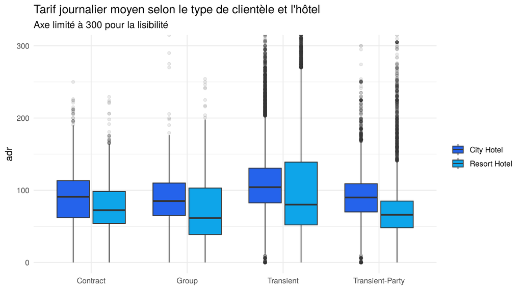

```r
ggplot(clean, aes(x = customer_type, y = adr, fill = hotel)) +
  geom_boxplot(outlier.alpha = 0.1) +
  scale_fill_manual(values = couleurs_hotel) +
  coord_cartesian(ylim = c(0, 300)) +
  labs(title = "Tarif journalier moyen selon le type de clientèle et l'hôtel",
       subtitle = "Axe limité à 300 pour la lisibilité", x = NULL, y = "adr", fill = NULL)
```

```r
test_b2  <- wilcox.test(adr ~ hotel, data = clean)
test_b2b <- kruskal.test(adr ~ customer_type, data = clean)
test_b2
```

```
##
##  Wilcoxon rank sum test with continuity correction
##
## data:  adr by hotel
## W = 2001535850, p-value < 2.2e-16
## alternative hypothesis: true location shift is not equal to 0
```

```r
test_b2b
```

```
##
##  Kruskal-Wallis rank sum test
##
## data:  adr by customer_type
## Kruskal-Wallis chi-squared = 4541.9, df = 3, p-value < 2.2e-16
```

```r
clean %>% group_by(customer_type) %>%
  summarise(n = n(), mediane_adr = median(adr), moyenne_adr = round(mean(adr), 2)) %>%
  arrange(desc(mediane_adr))
```

| customer_type | n | mediane_adr | moyenne_adr |
| --- | --- | --- | --- |
| Transient | 89474 | 99.00 | 107.10 |
| Contract | 4071 | 82.88 | 87.62 |
| Transient-Party | 25086 | 81.00 | 86.20 |
| Group | 574 | 75.00 | 83.91 |

Le tarif médian est de **99.98** au City Hotel contre **75** au Resort Hotel ; le test de Wilcoxon confirme la différence (p < 0,001). Le Resort Hotel présente toutefois une dispersion plus forte, liée à sa saisonnalité (tarifs très bas hors saison, très hauts en été). Selon le type de clientèle, le test de Kruskal-Wallis indique des différences significatives : la clientèle *Transient* paie le tarif médian le plus élevé (99) et la clientèle *Group* le plus bas (75), ce qui est cohérent avec les remises négociées pour les groupes et les contrats.

## Partie C : Catégorielle - Catégorielle

Pour chaque couple, on construit le tableau croisé, les pourcentages en ligne, le test du Khi-deux, puis le **V de Cramer**, calculé comme dans le cours à partir de la statistique du Khi-deux : `V = sqrt(chi2 / (N * min(r - 1, k - 1)))`. Il mesure l’intensité de l’association (0 = aucune, 1 = parfaite), indépendamment de la taille de l’échantillon.

Barème du cours (module 8, Cohen) : V < 0,10 négligeable ; 0,10 à 0,30 faible à modérée ; 0,30 à 0,50 modérée à forte ; V ≥ 0,50 très forte.

### C.1 Type d’hôtel et annulation (Q1)

```r
tab_c1 <- table(clean$hotel, clean$statut_annulation)
tab_c1
```

```
##
##                Non annulée Annulée
##   City Hotel         46082   33078
##   Resort Hotel       28926   11119
```

```r
round(100 * prop.table(tab_c1, margin = 1), 1)   # pourcentages en ligne
```

```
##
##                Non annulée Annulée
##   City Hotel          58.2    41.8
##   Resort Hotel        72.2    27.8
```

```r
chi_c1 <- chisq.test(tab_c1)
chi_c1
```

```
##
##  Pearson's Chi-squared test with Yates' continuity correction
##
## data:  tab_c1
## X-squared = 2239.9, df = 1, p-value < 2.2e-16
```

```r
chi_c1$expected                                   # effectifs attendus (tous >= 5 ?)
```

```
##
##                Non annulée  Annulée
##   City Hotel      49810.27 29349.73
##   Resort Hotel    25197.73 14847.27
```

```r
# V de Cramer
chi2_c1 <- as.numeric(chi_c1$statistic)
v_c1 <- sqrt(chi2_c1 / (sum(tab_c1) * min(nrow(tab_c1) - 1, ncol(tab_c1) - 1)))
round(v_c1, 3)
```

```
## [1] 0.137
```

### C.2 Type de dépôt et annulation (Q3)

```r
tab_c2 <- table(clean$deposit_type, clean$statut_annulation)
tab_c2
```

```
##
##              Non annulée Annulée
##   No Deposit       74789   29668
##   Non Refund          93   14493
##   Refundable         126      36
```

```r
round(100 * prop.table(tab_c2, margin = 1), 1)
```

```
##
##              Non annulée Annulée
##   No Deposit        71.6    28.4
##   Non Refund         0.6    99.4
##   Refundable        77.8    22.2
```

```r
chi_c2 <- chisq.test(tab_c2)
chi_c2
```

```
##
##  Pearson's Chi-squared test
##
## data:  tab_c2
## X-squared = 27640, df = 2, p-value < 2.2e-16
```

```r
chi_c2$expected
```

```
##
##              Non annulée     Annulée
##   No Deposit  65728.0370 38728.96295
##   Non Refund   9178.0268  5407.97317
##   Refundable    101.9361    60.06387
```

```r
chi2_c2 <- as.numeric(chi_c2$statistic)
v_c2 <- sqrt(chi2_c2 / (sum(tab_c2) * min(nrow(tab_c2) - 1, ncol(tab_c2) - 1)))
round(v_c2, 3)
```

```
## [1] 0.482
```

### C.3 Segment de marché et annulation (Q3)

```r
segments <- clean %>% filter(market_segment != "Inconnu")
tab_c3 <- table(as.character(segments$market_segment), segments$statut_annulation)
tab_c3
```

```
##
##                 Non annulée Annulée
##   Aviation              183      52
##   Complementary         639      89
##   Corporate            4290     991
##   Direct              10648    1934
##   Groups               7696   12094
##   Offline TA/TO       15880    8300
##   Online TA           35672   20735
```

```r
round(100 * prop.table(tab_c3, margin = 1), 1)
```

```
##
##                 Non annulée Annulée
##   Aviation             77.9    22.1
##   Complementary        87.8    12.2
##   Corporate            81.2    18.8
##   Direct               84.6    15.4
##   Groups               38.9    61.1
##   Offline TA/TO        65.7    34.3
##   Online TA            63.2    36.8
```

```r
chi_c3 <- chisq.test(tab_c3)
chi_c3
```

```
##
##  Pearson's Chi-squared test
##
## data:  tab_c3
## X-squared = 8496.3, df = 6, p-value < 2.2e-16
```

```r
chi_c3$expected
```

```
##
##                 Non annulée     Annulée
##   Aviation         147.8728    87.12721
##   Complementary    458.0910   269.90898
##   Corporate       3323.0476  1957.95236
##   Direct          7917.1720  4664.82798
##   Groups         12452.7765  7337.22348
##   Offline TA/TO  15215.1661  8964.83394
##   Online TA      35493.8739 20913.12605
```

```r
chi2_c3 <- as.numeric(chi_c3$statistic)
v_c3 <- sqrt(chi2_c3 / (sum(tab_c3) * min(nrow(tab_c3) - 1, ncol(tab_c3) - 1)))
round(v_c3, 3)
```

```
## [1] 0.267
```

La modalité « Inconnu » (2 réservations) est retirée de ce test : ses effectifs théoriques trop faibles fausseraient l’approximation du Khi-deux.

### C.4 Diagramme en proportions

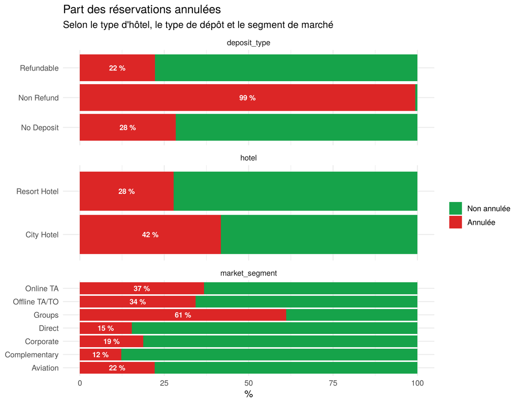

```r
# 1. Pourcentages par modalité pour les trois variables
proportions_df <- bind_rows(
  clean %>% count(modalite = as.character(hotel), statut_annulation) %>% mutate(variable = "hotel"),
  clean %>% count(modalite = as.character(deposit_type), statut_annulation) %>% mutate(variable = "deposit_type"),
  segments %>% count(modalite = as.character(market_segment), statut_annulation) %>% mutate(variable = "market_segment")
) %>%
  group_by(variable, modalite) %>%
  mutate(pourcentage = 100 * n / sum(n),
         etiquette = ifelse(statut_annulation == "Annulée", sprintf("%.0f %%", pourcentage), ""))

# 2. Barres empilées à 100 %
ggplot(proportions_df, aes(x = modalite, y = pourcentage, fill = statut_annulation)) +
  geom_col() +
  geom_text(aes(label = etiquette), position = position_stack(vjust = 0.5),
            colour = "white", size = 3.2, fontface = "bold") +
  coord_flip() +
  facet_wrap(~ variable, scales = "free_y", ncol = 1) +
  scale_fill_manual(values = couleurs_annul) +
  labs(title = "Part des réservations annulées",
       subtitle = "Selon le type d'hôtel, le type de dépôt et le segment de marché",
       x = NULL, y = "%", fill = NULL)
```

### C.5 Interprétation

| Association | Khi-deux (p-value) | V de Cramer | Intensité |
| --- | --- | --- | --- |
| `hotel` × annulation | p < 0,001 | 0.137 | Faible à modérée |
| `deposit_type` × annulation | p < 0,001 | 0.482 | Modérée à forte |
| `market_segment` × annulation | p < 0,001 | 0.267 | Faible à modérée |

- **Hôtel** : le City Hotel annule 41.8 % de ses réservations contre 27.8 % pour le Resort Hotel. L’association est significative mais d’intensité faible à modérée (V proche du bas de l’intervalle) : le type d’hôtel seul explique peu les annulations.
- **Type de dépôt** : résultat le plus marquant, avec l’association la plus forte des trois (modérée à forte, V proche de 0,5). Les réservations **non remboursables** sont annulées dans **99.4 %** des cas, contre 28.4 % sans dépôt. Ce résultat est contre-intuitif : un client qui a payé d’avance devrait moins annuler. Les réservations non remboursables proviennent presque toutes des segments *Groups* et *Offline TA/TO*, avec un délai médian de 183 jours. Le résultat est donc probablement lié à des pratiques d’agences ou de groupes qui bloquent des chambres en grand nombre (souvent avec un délai très long) puis libèrent celles qui ne sont pas vendues. Ce n’est donc pas le dépôt qui « cause » l’annulation, mais un type de réservation qui combine les deux.
- **Segment de marché** : le segment *Groups* présente le taux d’annulation le plus élevé (61.1 %) et le segment *Complementary* le plus faible (12.2 %). Les réservations d’agences en ligne, faciles à annuler, sont aussi parmi les plus annulées. L’association est faible à modérée, mais nettement plus marquée que pour le type d’hôtel.

**Précautions** : ces associations ne démontrent pas de causalité ; la p-value, quasi nulle partout, reflète surtout la grande taille de l’échantillon, d’où l’importance du V de Cramer pour juger l’intensité. Les doublons conservés peuvent aussi amplifier le poids de certains groupes dans ces tableaux.

# Mission 9 : Synthèse et recommandations

## 9.1 Rappel de la problématique

Nous cherchions à identifier les caractéristiques des réservations associées aux annulations et à comparer les comportements entre un hôtel urbain et un hôtel de villégiature, à travers cinq questions (Q1 à Q5).

## 9.2 Principaux résultats univariés

- Le City Hotel concentre environ deux tiers des réservations, et **37.1 %** de l’ensemble des réservations sont annulées.
- Le délai de réservation est très étalé (médiane de 69 jours, jusqu’à plus de 700 jours), les séjours sont courts (médiane de 3 nuits) et la très grande majorité des réservations concernent 2 adultes.
- La distribution passe surtout par les agences de voyage (en ligne et hors ligne), et la plupart des réservations sont faites sans dépôt.

## 9.3 Relations bivariées les plus intéressantes

| Question | Résultat | Intensité |
| --- | --- | --- |
| Q1 : annulation selon l’hôtel | City Hotel 41.8 % contre Resort Hotel 27.8 % | Faible à modérée (V = 0.14) |
| Q2 : délai et annulation | Délai médian 113 j (annulées) contre 45 j (non annulées) | Écart net, Wilcoxon p < 0,001 |
| Q3 : dépôt et annulation | Non Refund annulées à 99.4 % | Modérée à forte (V = 0.48) |
| Q3 : segment et annulation | *Groups* le plus annulé (61.1 %) | Faible à modérée (V = 0.27) |
| Q4 : tarif selon hôtel et clientèle | Tarif médian plus élevé au City Hotel ; tarifs plus bas pour les groupes et contrats | Différences significatives |
| Q5 : délai et tarif | Relation nulle au global, de sens opposés selon l’hôtel | Quasi nulle (ρ = 0.013) ; City -0.104, Resort 0.157 |

## 9.4 Problèmes de qualité et décisions de nettoyage

- **Valeurs manquantes** : `company` et `agent` sont absents par nature (pas d’entreprise ou d’agent) et ont été recodés « Aucun », sans imputation ; `country` a reçu une modalité « Inconnu » ; `children` a été imputé à 0.
- **Erreurs manifestes** : 185 lignes exclues (tarif négatif, tarif de 5 400, réservations sans occupant, 9 ou 10 bébés/enfants).
- **Doublons** : 31 994 lignes identiques conservées faute d’identifiant, avec un indicateur `is_duplicate`.
- **Valeurs atypiques** : les délais très longs, les grands groupes, les longs séjours et les tarifs nuls ont été conservés, car ils correspondent à des situations réelles.

## 9.5 Limites de l’analyse

- **Absence d’identifiant de réservation** : il est impossible de distinguer un vrai doublon d’une réservation multiple ; selon le choix, le taux d’annulation passe de 37 % à 27.5 %.
- **Deux hôtels seulement**, situés au Portugal, sur la période 2015-2017 : les résultats ne se généralisent pas à tout le secteur hôtelier, ni à la période post-pandémie.
- **Analyse uniquement bivariée** : des facteurs de confusion (par exemple segment et dépôt, délai et segment) ne sont pas contrôlés ; aucune conclusion causale n’est possible.
- **Variables absentes** : prix payé total, motif d’annulation, date d’annulation, caractéristiques des chambres.
- **Méthode IQR peu adaptée** aux variables de comptage concentrées (`adults`, `booking_changes`), d’où le besoin d’un examen métier au cas par cas.

## 9.6 Recommandations pour les établissements

1. **Encadrer les réservations très anticipées** : relancer les clients et demander une confirmation à mesure que l’arrivée approche, en particulier au-delà de 90 jours.
2. **Revoir les accords avec les groupes et agences hors ligne** dont les réservations non remboursables sont massivement annulées : quotas de libération, pénalités réelles, suivi par agent.
3. **Ajuster la surréservation par segment** : appliquer un taux de surréservation plus élevé aux segments les plus annulés (agences, groupes) et plus prudent pour les segments fiables (*Direct*, *Corporate*).
4. **Améliorer la collecte de données** : ajouter un identifiant unique de réservation, rendre le pays obligatoire à la réservation, contrôler la saisie des tarifs et du nombre d’occupants.

## 9.7 Nouvelles questions analytiques

1. Le taux d’annulation varie-t-il selon la saison et le mois d’arrivée, et cette saisonnalité diffère-t-elle entre les deux hôtels ?
2. Les clients ayant déjà annulé (`previous_cancellations`) ou les clients fidèles (`is_repeated_guest`) annulent-ils plus ou moins souvent ?
3. Une demande spéciale (`total_of_special_requests`) ou une place de stationnement (`required_car_parking_spaces`) est-elle associée à un plus faible taux d’annulation ?
4. Avec des données complémentaires (date d’annulation), à quel moment avant l’arrivée les annulations surviennent-elles ?

# Déclaration de contribution

| Membre | Contributions principales | Parties réalisées |
| --- | --- | --- |
| Yacine Lezoul (2748526) | Conception de la problématique, code R, analyses statistiques, visualisations, nettoyage des données, interprétations et rédaction | Missions 1 à 9 (projet réalisé seul) |